# Rapport du TP5 de statistique exploratoire

Rémy Gaudré

18/10/2019

## Importation des données

```
##   Annee temp inso chal pluie Qualite QualiteMoyen
## 1  1924 3064 1201   10   361       2        Moyen
## 2  1925 3000 1053   11   338       3     Mediocre
## 3  1926 3155 1133   19   393       2        Moyen
## 4  1927 3085  970    4   467       3     Mediocre
## 5  1928 3245 1258   36   294       1          Bon
## 6  1929 3267 1386   35   225       1          Bon
```

## 1. Tracer et analyser les boîtes à moustaches de chacune des variables explicatives par rapport aux modalités de la variable de groupe “qualité des vins”

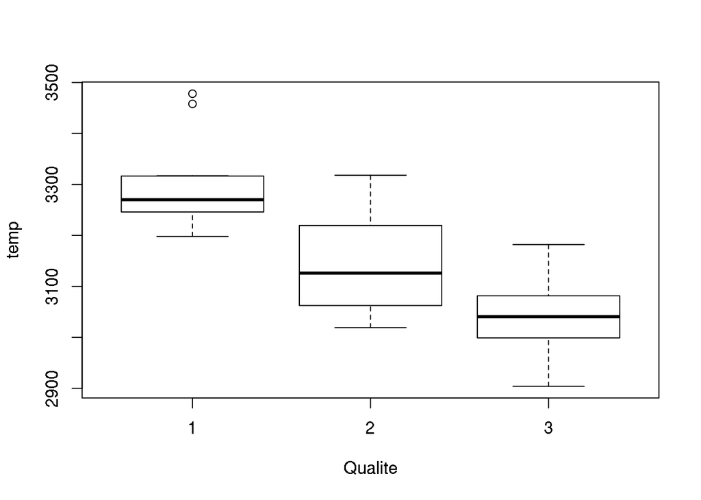

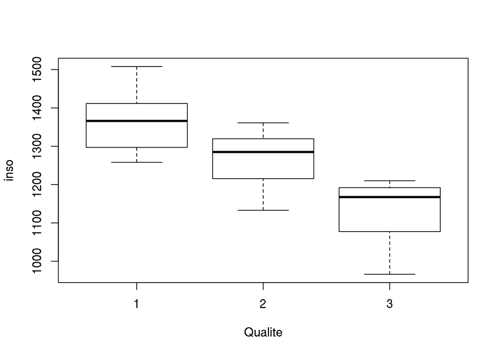

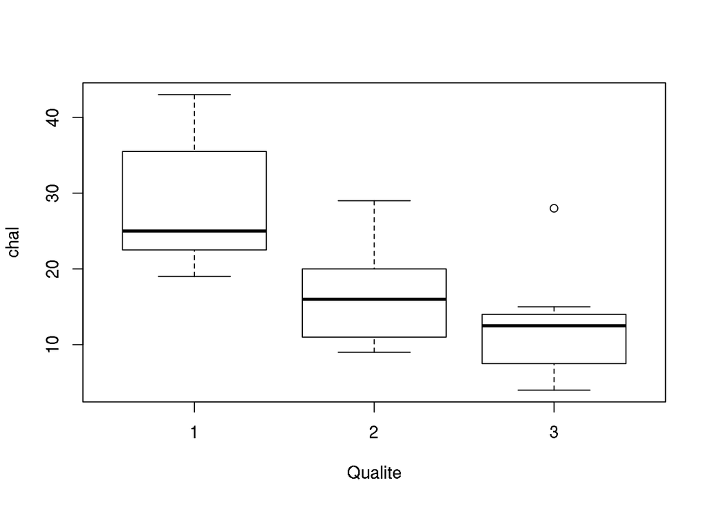

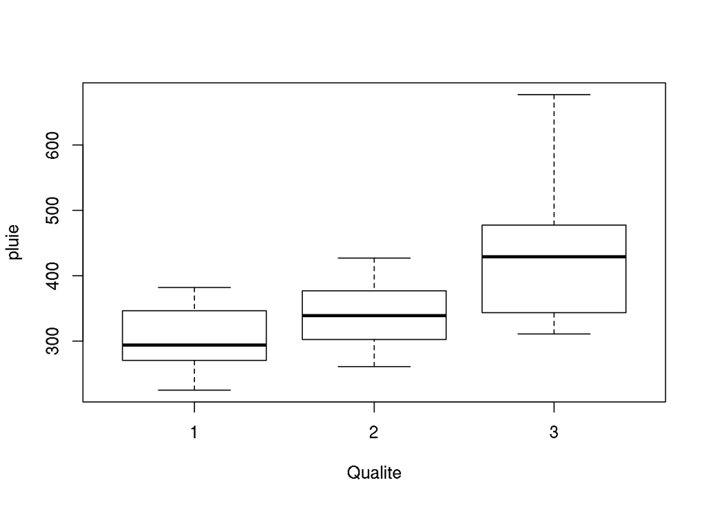

On observe que :

- plus la somme des températures moyenne journalière dimininue plus la qualité des vins a tendance à être mauvaise.
- plus la durée d’insolation diminue, plus la qualité qualité des vins a tendance à être mauvaise.
- plus le nombre de jour de grande chaleur diminue, plus la qualité des vins a tendance à être mauvaise.
- plus la hauteur des pluies augmente, plus la qualité des vins a tendance à être mauvaise.

## 2. Estimer le pouvoir discriminant de chacune des variables explicatives par rapport à la variable Qualité des vins : Le rapport de la variance inter-classes (variance expliquée) sur variance totale.

Tableau d’analyse du pouvoir discriminant de chaque variable explicative sur la qualité des vins

|  | correl_ratio | wilks_lambda | F_statistic | p_value |
| --- | --- | --- | --- | --- |
| temp | 0.6342087 | 0.3657913 | 26.873887 | 0.0000002 |
| inso | 0.6178571 | 0.3821429 | 25.060741 | 0.0000003 |
| chal | 0.4973118 | 0.5026882 | 15.334220 | 0.0000234 |
| pluie | 0.3525374 | 0.6474626 | 8.439607 | 0.0011853 |

Le test d’hypothèse teste la significativité du rapport de correlation :

- $H_0$ : “Le rapport de correlation est égal à 1”
- $H_1$ : “Le rapport de correlation est inférieur à 1”.

Le test statistique est donc un test d’égalité des variances. On observe que toutes les p-value sont inférieures à 5% : les tests sont tous significatifs. Les plus intéressant sont ceux qui concerne les variables temp et inso. Les variables temp et inso ont donc le plus grand pouvoir discriminant sur la variable qualité des vins.

## 3. Tester l’égalité des moyennes de chacune des variables explicatives à traver les groupes de la variable dépendante. (Test de Lambda de Wilks) On posera convenablement les hypothèses nulle et alternative.

```
## donnees$Qualite ~ temp + inso + pluie + chal
## <environment: 0x560c1e894518>
```

| vars | Wilks.lambda | F.statistics.overall | p.value.overall | F.statistics.diff | p.value.diff |
| --- | --- | --- | --- | --- | --- |
| temp | 0.3657913 | 26.873887 | 2e-07 | 26.873887 | 0.0000002 |
| inso | 0.2612613 | 14.346327 | 0e+00 | 6.001468 | 0.0062645 |
| pluie | 0.2189449 | 10.992335 | 0e+00 | 2.802472 | 0.0765886 |
| chal | 0.2026627 | 8.549312 | 2e-07 | 1.124783 | 0.3384802 |

## 4. Tester l’égalité des matrices de variance-covariance de chacun des groupes de la variable dépendante. (Test de BOX de l’égalité des matrices de covariances) On posera convenablement les hypothèses nulle et alternative.

```
##
##  Box's M-test for Homogeneity of Covariance Matrices
##
## data:  donnees[, 2:5]
## Chi-Sq (approx.) = 24.263, df = 20, p-value = 0.2311
```

Ce test compare les matrice de variance-covariances de chacun des groupes de la variable dépendante. Les hypothèses sont les suivantes :

- $H_0$ : “Les matrices de variance-covariance sont égales”
- $H_1$ : “Au moins une des matrices de variance-covariance ne sont pas égales”

La p-value de ce test est égale à 0.2311. On accepte donc $H_0$ les variances ne sont pas significativement différentes.

## 5. Analyse discriminante linéaire (ou Analyse Factorielle Discriminante)

```
## Call:
## lda(donnees[, 2:5], donnees$QualiteMoyen)
##
## Prior probabilities of groups:
##       Bon  Mediocre     Moyen
## 0.3235294 0.3529412 0.3235294
##
## Group means:
##              temp     inso     chal    pluie
## Bon      3302.273 1363.636 28.54545 305.0000
## Mediocre 3037.333 1126.417 12.08333 430.3333
## Moyen    3140.909 1262.909 16.45455 339.6364
##
## Coefficients of linear discriminants:
##                LD1          LD2
## temp  -0.008999814 -0.001012746
## inso  -0.006892240 -0.004952708
## chal   0.032874491  0.137599601
## pluie  0.006016386  0.006092626
##
## Proportion of trace:
##    LD1    LD2
## 0.9599 0.0401
```

### Estimer le pouvoir discriminant de chacun des facteurs issus de l’AFD

Tableau d’analyse du pouvoir discriminant de chaque variable explicative sur la qualité des vins

[output not shown]